# P8105 HW2

Kaitlyn Wang

```r
library(tidyverse)
library(tidyr)
library(dplyr)
```

## Problem 1

Read and clean the Mr. Trash Wheel sheet:

```r
trash_wheel =
  readxl::read_excel("./data/TWC.xlsx", sheet = "Mr. Trash Wheel", range = "A2:N535") %>%
  janitor::clean_names() %>%
  filter(dumpster != "NA") %>%
  mutate(sports_balls = round(sports_balls, digits = 0))
```

Read and clean precipitation data for 2018 and 2019.

```r
prcp2018 = readxl::read_excel("./data/TWC.xlsx", sheet = "2018 Precipitation", skip = 1) %>%
  janitor::clean_names() %>%
  drop_na() %>%
  mutate(year = 2018)

prcp2019 = readxl::read_excel("./data/TWC.xlsx", sheet = "2019 Precipitation", skip = 1) %>%
  janitor::clean_names() %>%
  drop_na() %>%
  mutate(year = 2019)

prcp = full_join(prcp2018, prcp2019) %>%
  mutate(month = month.name[month])
```

The Mr. Trash Wheel dataset contains 454 observations in 14 categories. For example, year, months, and multiples trash categories.

The precipitation dataset contains 24 rows and 3 columns, including months, precipitation and year. The total precipitation in 2018 is 70.33 and the median number of sports balls in a dumpster in 2019 is 9.

## Problem 2

First, clean the data in pols-month.csv.

```r
pols_month = read_csv("./data/datasets/pols-month.csv") %>%
  janitor::clean_names() %>%
  separate(mon, into = c("year", "month", "day")) %>%
  mutate(month = as.numeric(month), year = as.numeric(year)) %>%
  mutate(month = month.name[month]) %>%
  mutate(president = ifelse(prez_gop == 0, "dem", "gop")) %>%
  select(-c(prez_dem,prez_gop,day))
```

Second, clean the data in snp.csv.

```r
snp = read_csv("./data/datasets/snp.csv") %>%
  separate(date, into = c("month", "day", "year")) %>%
  mutate(month = as.numeric(month), year = as.numeric(year)) %>%
  mutate(year = ifelse(year < 50, year + 2000, year + 1900)) %>%
  arrange(year, month) %>%
  mutate(month = month.name[month]) %>%
  relocate(year, month)
```

Third, tidy the unemployment data so that it can be merged with the previous datasets.

```r
unemploy = read_csv("./data/datasets/unemployment.csv") %>%
  rename(year = Year) %>%
  pivot_longer(
    Jan:Dec,
    names_to = "month",
    values_to = "pct_unemployed"
    ) %>%
  mutate(month = match(month, month.abb)) %>%
  mutate(month = month.name[month])
```

Join the datasets by merging snp into pols, and merging unemployment into the result.

```r
list1 = left_join(pols_month, snp)
list2 = left_join(list1, unemploy)
```

The dataset contains 822 rows ranging from year 1947 to year 2015; and 12 columns with information including whether the president is republican or democrat and the number of senator, governor and representative in each party in different time.

## Problem 3

Load and tidy the data.

```r
names_raw = read_csv("./data/Popular_Baby_Names.csv") %>%
  janitor::clean_names() %>%
  mutate(childs_first_name = tolower(childs_first_name)) %>%
  distinct()
unique(pull(names_raw, ethnicity))
```

```
## [1] "ASIAN AND PACIFIC ISLANDER" "BLACK NON HISPANIC"
## [3] "HISPANIC"                   "WHITE NON HISPANIC"
## [5] "ASIAN AND PACI"             "BLACK NON HISP"
## [7] "WHITE NON HISP"
```

```r
names =
  names_raw %>%
  mutate(ethnicity = replace(ethnicity, ethnicity == "WHITE NON HISP", "WHITE NON HISPANIC")) %>%
  mutate(ethnicity = replace(ethnicity, ethnicity == "ASIAN AND PACI","ASIAN AND PACIFIC ISLANDER")) %>%
  mutate(ethnicity = replace(ethnicity, ethnicity == "BLACK NON HISP", "BLACK NON HISPANIC"))
```

Produce a well-structured, reader-friendly table showing the rank in popularity of the name “Olivia” as a female baby name over time; this should have rows for ethnicities and columns for year.

```r
olivia =
  names %>%
  filter(childs_first_name == "olivia") %>%
  select(year_of_birth, ethnicity, rank) %>%
  pivot_wider(
    names_from = "year_of_birth",
    values_from = "rank"
  ) %>%
  relocate(ethnicity, "2011", "2012", "2013", "2014", "2015", "2016")
```

Produce a similar table showing the most popular name among male children over time.

```r
male_pop =
  names %>%
  filter(gender == "MALE") %>%
  group_by(childs_first_name) %>%
  summarise(total = sum(count)) %>%
  arrange(desc(total))

ethan =
  names %>%
  filter(childs_first_name == "ethan") %>%
  select(year_of_birth, ethnicity, rank) %>%
  pivot_wider(
    names_from = "year_of_birth",
    values_from = "rank"
  ) %>%
  relocate(ethnicity, "2011", "2012", "2013", "2014", "2015", "2016")
```

Finally, for male, white non-hispanic children born in 2016, produce a scatter plot showing the number of children with a name (y axis) against the rank in popularity of that name (x axis).

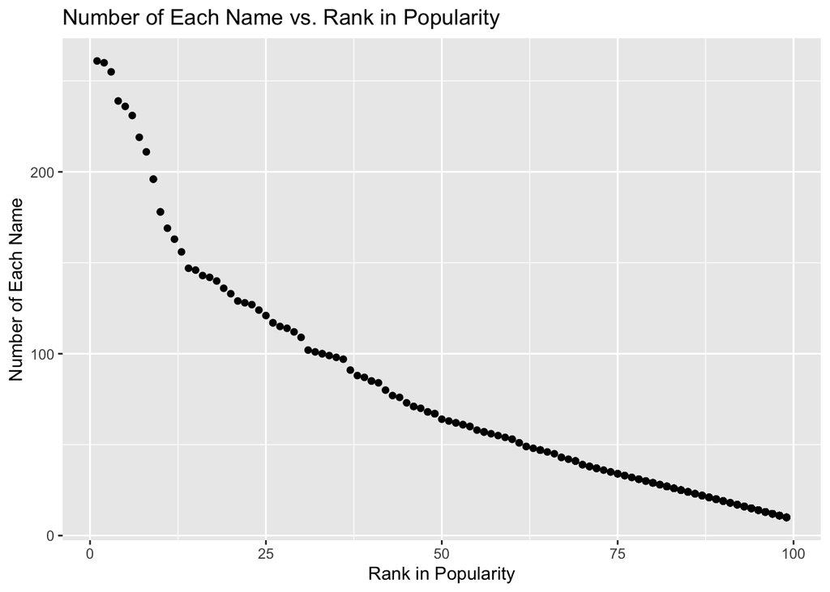

```r
white_2016 =
  names %>%
  filter(gender == "MALE", year_of_birth == "2016", ethnicity == "WHITE NON HISPANIC")

ggplot(white_2016, aes(x = rank, y = count)) + geom_point() +
  labs(
    title = "Number of Each Name vs. Rank in Popularity",
    x = "Rank in Popularity",
    y = "Number of Each Name"
  )
```